# Tugas 4 Kelompok 11

Anggota Kelompok :

1. Erlin Shofiana (22/493520/PA/21196)
2. Annisa Sekartierra Mulyanto (22/494177/PA/21257)
3. Cintya Kusumawardhani (22/502898/PA/21591)

# Resampled Efficient Frontier (REF)

## Metodologi

Metode `Resampled Efficient Frontier (REF)` adalah teknik dalam optimisasi portofolio yang bertujuan untuk mengatasi ketidakpastian dalam estimasi parameter, seperti **return** dan **covariance** antar aset, yang sering kali rentan terhadap sensitivitas tinggi dalam model **Mean-Variance Markowitz**. Metode tradisional ini sangat bergantung pada data historis, sehingga perubahan kecil dalam estimasi parameter dapat menghasilkan perbedaan signifikan dalam alokasi portofolio optimal. Untuk mengatasi masalah **overfitting**, REF menggunakan pendekatan **resampling** melalui teknik seperti **Monte Carlo simulation** atau **bootstrapping**, yang mensimulasikan berbagai skenario return aset berdasarkan estimasi historis, mencerminkan ketidakpastian dan volatilitas pasar.

Setiap simulasi menghasilkan **Efficient Frontier** yang berbeda, dan setelah menjalankan banyak simulasi, rata-rata dari semua frontier tersebut diambil. Ini menciptakan portofolio yang lebih **robust** dan tidak terlalu bergantung pada satu set data historis tertentu. Hasilnya adalah alokasi portofolio yang lebih stabil, realistis, dan kurang rentan terhadap kesalahan estimasi parameter. Dengan demikian, REF memberikan solusi yang lebih andal dalam menghadapi kondisi pasar yang dinamis, menjadikannya pilihan yang lebih tahan terhadap volatilitas dan ketidakpastian pasar.

## Data

```python
import pandas as pd
import numpy as np
from scipy import stats

import pandas as pd

data = pd.read_excel('PMI.xlsx', sheet_name='ref', parse_dates=True)
data.drop(['Date'],axis=1,inplace=True)
data
```

|  | BBCA | BBRI | BMRI |
| --- | --- | --- | --- |
| 0 | 10075 | 4840 | 6400 |
| 1 | 10075 | 4900 | 6425 |
| 2 | 10050 | 4820 | 6350 |
| 3 | 9950 | 4730 | 6350 |
| 4 | 10100 | 4890 | 6550 |
| 5 | 10125 | 4900 | 6525 |
| 6 | 10100 | 4910 | 6700 |
| 7 | 10175 | 4790 | 6625 |
| 8 | 10075 | 4780 | 6475 |
| 9 | 10300 | 4700 | 6575 |
| 10 | 10325 | 4760 | 6550 |
| 11 | 10250 | 4780 | 6475 |
| 12 | 10175 | 4670 | 6475 |
| 13 | 10275 | 4670 | 6400 |
| 14 | 10375 | 4750 | 6750 |
| 15 | 10200 | 4710 | 6800 |
| 16 | 9875 | 4530 | 6575 |
| 17 | 10000 | 4600 | 6625 |
| 18 | 10100 | 4620 | 6775 |
| 19 | 10225 | 4660 | 6800 |
| 20 | 10150 | 4670 | 6850 |
| 21 | 10200 | 4680 | 6900 |
| 22 | 10300 | 4720 | 7000 |
| 23 | 10200 | 4820 | 7075 |
| 24 | 10225 | 4830 | 7025 |
| 25 | 10325 | 4830 | 7075 |
| 26 | 10375 | 4820 | 7150 |
| 27 | 10425 | 4950 | 7200 |
| 28 | 10425 | 5100 | 7250 |
| 29 | 10325 | 5050 | 7050 |
| 30 | 10325 | 5150 | 7050 |
| 31 | 10325 | 5300 | 7050 |
| 32 | 10200 | 5175 | 7025 |
| 33 | 10350 | 5150 | 7225 |
| 34 | 10225 | 5125 | 7100 |
| 35 | 10325 | 5150 | 7125 |
| 36 | 10275 | 5175 | 7200 |
| 37 | 10175 | 5175 | 7075 |
| 38 | 10300 | 5100 | 7175 |
| 39 | 10250 | 5150 | 7175 |
| 40 | 10300 | 5225 | 7250 |
| 41 | 10275 | 5175 | 7250 |
| 42 | 10350 | 5250 | 7250 |
| 43 | 10425 | 5175 | 7375 |

Return logaritmik digunakan untuk menghitung perubahan harga aset dari waktu ke waktu, karena return ini lebih akurat dalam memperhitungkan perubahan nilai yang kecil dibandingkan return aritmatika.

```python
# Calculate log returns
df_log_returns = np.log(data / data.shift(1))

# Drop the NaN values (which result from the first row after calculating returns)
df_log_returns.dropna(inplace=True)

df_log_returns
```

|  | BBCA | BBRI | BMRI |
| --- | --- | --- | --- |
| 1 | 0.000000 | 0.012320 | 0.003899 |
| 2 | -0.002484 | -0.016461 | -0.011742 |
| 3 | -0.010000 | -0.018849 | 0.000000 |
| 4 | 0.014963 | 0.033267 | 0.031010 |
| 5 | 0.002472 | 0.002043 | -0.003824 |
| 6 | -0.002472 | 0.002039 | 0.026467 |
| 7 | 0.007398 | -0.024744 | -0.011257 |
| 8 | -0.009877 | -0.002090 | -0.022902 |
| 9 | 0.022087 | -0.016878 | 0.015326 |
| 10 | 0.002424 | 0.012685 | -0.003810 |
| 11 | -0.007290 | 0.004193 | -0.011516 |
| 12 | -0.007344 | -0.023281 | 0.000000 |
| 13 | 0.009780 | 0.000000 | -0.011651 |
| 14 | 0.009685 | 0.016986 | 0.053245 |
| 15 | -0.017011 | -0.008457 | 0.007380 |
| 16 | -0.032381 | -0.038966 | -0.033648 |
| 17 | 0.012579 | 0.015334 | 0.007576 |
| 18 | 0.009950 | 0.004338 | 0.022389 |
| 19 | 0.012300 | 0.008621 | 0.003683 |
| 20 | -0.007362 | 0.002144 | 0.007326 |
| 21 | 0.004914 | 0.002139 | 0.007273 |
| 22 | 0.009756 | 0.008511 | 0.014389 |
| 23 | -0.009756 | 0.020965 | 0.010657 |
| 24 | 0.002448 | 0.002073 | -0.007092 |
| 25 | 0.009732 | 0.000000 | 0.007092 |
| 26 | 0.004831 | -0.002073 | 0.010545 |
| 27 | 0.004808 | 0.026614 | 0.006969 |
| 28 | 0.000000 | 0.029853 | 0.006920 |
| 29 | -0.009639 | -0.009852 | -0.027974 |
| 30 | 0.000000 | 0.019608 | 0.000000 |
| 31 | 0.000000 | 0.028710 | 0.000000 |
| 32 | -0.012180 | -0.023867 | -0.003552 |
| 33 | 0.014599 | -0.004843 | 0.028072 |
| 34 | -0.012151 | -0.004866 | -0.017452 |
| 35 | 0.009732 | 0.004866 | 0.003515 |
| 36 | -0.004854 | 0.004843 | 0.010471 |
| 37 | -0.009780 | 0.000000 | -0.017514 |
| 38 | 0.012210 | -0.014599 | 0.014035 |
| 39 | -0.004866 | 0.009756 | 0.000000 |
| 40 | 0.004866 | 0.014458 | 0.010399 |
| 41 | -0.002430 | -0.009615 | 0.000000 |
| 42 | 0.007273 | 0.014389 | 0.000000 |
| 43 | 0.007220 | -0.014389 | 0.017094 |

## Algoritma

```python
import numpy as np
import pandas as pd
import matplotlib.pyplot as plt
from scipy.optimize import minimize
```

### 1. Menghitung Global Minimum Variance Portfolio (GMVP)

Langkah ini bertujuan untuk menghitung portofolio dengan variansi terendah, yang dikenal sebagai **Global Minimum Variance Portfolio (GMVP)**. Pada tahap ini, dihitung bobot portofolio yang meminimalkan variansi.

- `Fungsi portfolio_variance`: Menghitung variansi portofolio berdasarkan bobot dan matriks kovarians.
- `Fungsi compute_gmvp`: Mengoptimasi variansi portofolio untuk menemukan GMVP.

```python
# Fungsi untuk menghitung variansi portofolio
def portfolio_variance(weights, cov_matrix):
    return weights.T @ cov_matrix @ weights
```

```python
# Fungsi untuk menghitung Global Minimum Variance Portfolio (GMVP)
def compute_gmvp(cov_matrix):
    num_assets = len(cov_matrix)
    args = (cov_matrix,)
    constraints = ({'type': 'eq', 'fun': lambda x: np.sum(x) - 1})
    bounds = tuple((0, 1) for asset in range(num_assets))
    result = minimize(portfolio_variance, num_assets*[1./num_assets,], args=args,
                      method='SLSQP', bounds=bounds, constraints=constraints)
    return result.x
```

- `num_assets`: Menghitung jumlah aset berdasarkan matriks kovarians
- `args`: Menyimpan argumen untuk fungsi optimasi
- `constraints`: Membuat batasan bahwa jumlah bobot portofolio harus sama dengan 1
- `bounds`: Membatasi setiap bobot aset antara 0 dan 1
- `result`: Menggunakan fungsi minimize untuk mencari bobot yang meminimalkan variansi portofolio
- `return result.x`: Mengembalikan bobot optimal untuk GMVP

### 2. Menghitung Portofolio Mean-Variance

Portofolio optimal untuk target return tertentu dihitung dengan mempertimbangkan dua batasan: **total bobot harus 1** dan **return portofolio harus sama dengan target return**.

```python
# Fungsi untuk optimasi Mean-Variance untuk target return tertentu (2 constraints)
def min_variance_for_target_return(mean_returns, cov_matrix, target_return):
    num_assets = len(mean_returns)
    args = (cov_matrix,)
    constraints = (
        {'type': 'eq', 'fun': lambda x: np.sum(x) - 1},  # Bobot total = 1
        {'type': 'eq', 'fun': lambda x: x @ mean_returns - target_return}  # Return portofolio = target_return
    )
    bounds = tuple((0, 1) for asset in range(num_assets))
    result = minimize(portfolio_variance, num_assets*[1./num_assets,], args=args,
                      method='SLSQP', bounds=bounds, constraints=constraints)
    return result.x
```

### 3. Menghitung Resampled Efficient Frontier (REF)

Bagian utama dari metode REF adalah melakukan simulasi resampling return untuk mendapatkan berbagai skenario portofolio, lalu menghitung efisien frontier untuk setiap skenario tersebut.

- Setiap simulasi menghasilkan data return baru menggunakan distribusi normal multivariat berdasarkan mean return dan covariance historis.
- Dengan menggunakan bobot GMVP sebagai titik awal, frontier dihitung dari GMVP hingga return maksimum pada setiap simulasi.
- Hasil dari setiap simulasi (risiko, return, dan bobot portofolio) disimpan untuk analisis lebih lanjut.

```python
# Fungsi utama untuk Resampled Efficient Frontier
def resampled_efficient_frontier(returns_df, num_simulations=700, num_points=25):
    num_assets = returns_df.shape[1] #3
    T = returns_df.shape[0] #43
    assets = returns_df.columns #3

    # Estimasi mean dan covariance dari data historis
    historical_mean = returns_df.mean()
    historical_cov = returns_df.cov()

    # List untuk menyimpan hasil final
    final_results = []

    # Simpan hasil simulasi (risiko dan return portofolio)
    all_frontiers = []
    all = []

    for q in range(num_simulations):
        # Simulasi resampling return menggunakan distribusi normal multivariat
        simulated_returns = np.random.multivariate_normal(historical_mean, historical_cov, T) #43,3
        simulated_returns = pd.DataFrame(simulated_returns, columns=assets)

        # Estimasi mean dan covariance dari data simulasi
        sim_mean = simulated_returns.mean()
        sim_cov = simulated_returns.cov()

        # Hitung GMVP untuk data simulasi
        gmvp_weights = compute_gmvp(sim_cov)
        gmvp_return = gmvp_weights @ sim_mean

        # Return maksimum dari aset
        max_return = sim_mean.max()

        # Tentukan rentang target return dari GMVP hingga return maksimum
        target_returns = np.linspace(gmvp_return, max_return, num_points)

        # Untuk menyimpan risiko dan return di setiap simulasi
        risks = []
        returns = []
        weights_list1 = []
        weights_list2 = []
        weights_list3 = []

        # Untuk setiap target return, lakukan optimasi
        for target_return in target_returns:
            weights = min_variance_for_target_return(sim_mean.values, sim_cov.values, target_return)
            portfolio_return = weights @ sim_mean
            portfolio_risk = np.sqrt(portfolio_variance(weights, sim_cov))

            # Simpan risiko, return, dan bobot untuk setiap titik
            risks.append(portfolio_risk)
            returns.append(portfolio_return)
            weights_list1.append(weights[0])
            weights_list2.append(weights[1])
            weights_list3.append(weights[2])


            # Simpan hasil dalam final_results
            final_results.append({
                'Return': portfolio_return,
                'Risk': portfolio_risk,
                assets[0]: weights[0],  # BBCA
                assets[1]: weights[1],  # BBRI
                assets[2]: weights[2]   # BMRI
            })

        all_frontiers.append((risks, returns))
        all.append((risks, returns, weights_list1, weights_list2, weights_list3))

    # Ubah hasil final ke dalam DataFrame
    final_results_df = pd.DataFrame(final_results)

    return final_results_df, all_frontiers, all
```

### 4. Visualisasi Efficient Frontier

Setelah hasil simulasi dikumpulkan, frontier yang berbeda-beda dari setiap simulasi ditampilkan dalam grafik.

```python
# Fungsi untuk memvisualisasikan frontier
def plot_resampled_efficient_frontier(all_frontiers):
    plt.figure(figsize=(10, 6))
    for risks, returns in all_frontiers:
        plt.plot(risks, returns, lw=0.7)  # Garis tipis untuk setiap simulasi

    plt.title('Resampled Efficient Frontier')
    plt.xlabel('Risiko Portofolio')
    plt.ylabel('Return Portofolio')
    plt.grid(True)
    plt.show()
```

# Hasil

```python
# Jika sudah memiliki dataframe 'returns_df', panggil fungsi berikut
final_results_df, all_frontiers, all = resampled_efficient_frontier(returns_df=df_log_returns, num_simulations=700, num_points=25)

# Tampilkan tabel hasil
print(final_results_df)
```

```
         Return      Risk          BBCA      BBRI      BMRI
0      0.001624  0.010050  3.333333e-01  0.333333  0.333333
1      0.001766  0.010111  3.142693e-01  0.326578  0.359153
2      0.001908  0.010182  2.951990e-01  0.319832  0.384969
3      0.002051  0.010261  2.761287e-01  0.313085  0.410786
4      0.002193  0.010349  2.570584e-01  0.306339  0.436603
...         ...       ...           ...       ...       ...
17495  0.000590  0.012715  4.722432e-01  0.052519  0.475237
17496  0.000647  0.012804  4.791865e-01  0.038479  0.482335
17497  0.000705  0.012898  4.861298e-01  0.024438  0.489432
17498  0.000762  0.012994  4.930732e-01  0.010397  0.496529
17499  0.000820  0.015994  2.159481e-07  0.000000  1.000000

[17500 rows x 5 columns]
```

## Visualisasi

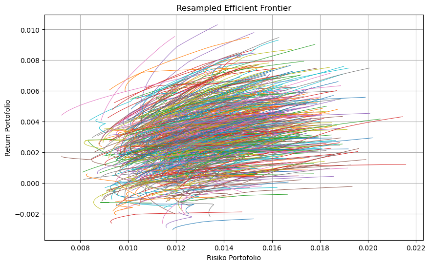

```python
plot_resampled_efficient_frontier(all_frontiers)
```

## Bobot Portofolio

Rata-rata bobot portofolio untuk setiap skenario dihitung untuk memberikan panduan bagi investor terkait proporsi investasi pada setiap aset.

```python
# Convert all_frontiers to a 3D NumPy array for easier manipulation
all_array = np.array(all)

# Calculate the average across the first axis (across all 700 arrays)
average_all = np.mean(all_array, axis=0)

# Convert the result back to a DataFrame for easy viewing (optional)

df_average = pd.DataFrame(average_all)

# Display the averaged DataFrame
df_average
```

|  | 0 | 1 | 2 | 3 | 4 | 5 | 6 | 7 | 8 | 9 | ... | 15 | 16 | 17 | 18 | 19 | 20 | 21 | 22 | 23 | 24 |
| --- | --- | --- | --- | --- | --- | --- | --- | --- | --- | --- | --- | --- | --- | --- | --- | --- | --- | --- | --- | --- | --- |
| 0 | 0.011203 | 0.011272 | 0.011350 | 0.011436 | 0.011529 | 0.011631 | 0.011740 | 0.011856 | 0.011980 | 0.012110 | ... | 0.013023 | 0.013195 | 0.013386 | 0.013595 | 0.013823 | 0.014074 | 0.014351 | 0.014660 | 0.015033 | 0.015531 |
| 1 | 0.001908 | 0.001987 | 0.002065 | 0.002144 | 0.002223 | 0.002302 | 0.002381 | 0.002460 | 0.002539 | 0.002618 | ... | 0.003091 | 0.003170 | 0.003248 | 0.003327 | 0.003406 | 0.003485 | 0.003564 | 0.003643 | 0.003722 | 0.003800 |
| 2 | 0.333333 | 0.322556 | 0.311739 | 0.300922 | 0.290105 | 0.279288 | 0.268471 | 0.257655 | 0.246838 | 0.236021 | ... | 0.171119 | 0.160302 | 0.147583 | 0.134740 | 0.122007 | 0.109296 | 0.096470 | 0.084357 | 0.071391 | 0.057148 |
| 3 | 0.333333 | 0.329648 | 0.325982 | 0.322316 | 0.318651 | 0.314985 | 0.311320 | 0.307654 | 0.303989 | 0.300323 | ... | 0.278330 | 0.274664 | 0.271058 | 0.266544 | 0.261199 | 0.255634 | 0.250830 | 0.245521 | 0.237969 | 0.231433 |
| 4 | 0.333333 | 0.347796 | 0.362279 | 0.376761 | 0.391244 | 0.405726 | 0.420209 | 0.434691 | 0.449174 | 0.463656 | ... | 0.550551 | 0.565034 | 0.581359 | 0.598716 | 0.616794 | 0.635070 | 0.652700 | 0.670122 | 0.690640 | 0.711418 |

5 rows × 25 columns

```python
# Melakukan transpose
df_avg = df_average.T

df_avg.columns = ['Risk_Avg', 'Return_Avg', 'Weight_BBCA', 'Weight_BBRI', 'Weight_BMRI']
df_avg
```

|  | Risk_Avg | Return_Avg | Weight_BBCA | Weight_BBRI | Weight_BMRI |
| --- | --- | --- | --- | --- | --- |
| 0 | 0.011203 | 0.001908 | 0.333333 | 0.333333 | 0.333333 |
| 1 | 0.011272 | 0.001987 | 0.322556 | 0.329648 | 0.347796 |
| 2 | 0.011350 | 0.002065 | 0.311739 | 0.325982 | 0.362279 |
| 3 | 0.011436 | 0.002144 | 0.300922 | 0.322316 | 0.376761 |
| 4 | 0.011529 | 0.002223 | 0.290105 | 0.318651 | 0.391244 |
| 5 | 0.011631 | 0.002302 | 0.279288 | 0.314985 | 0.405726 |
| 6 | 0.011740 | 0.002381 | 0.268471 | 0.311320 | 0.420209 |
| 7 | 0.011856 | 0.002460 | 0.257655 | 0.307654 | 0.434691 |
| 8 | 0.011980 | 0.002539 | 0.246838 | 0.303989 | 0.449174 |
| 9 | 0.012110 | 0.002618 | 0.236021 | 0.300323 | 0.463656 |
| 10 | 0.012247 | 0.002696 | 0.225204 | 0.296657 | 0.478139 |
| 11 | 0.012390 | 0.002775 | 0.214387 | 0.292992 | 0.492621 |
| 12 | 0.012539 | 0.002854 | 0.203570 | 0.289326 | 0.507104 |
| 13 | 0.012695 | 0.002933 | 0.192753 | 0.285661 | 0.521586 |
| 14 | 0.012856 | 0.003012 | 0.181936 | 0.281995 | 0.536069 |
| 15 | 0.013023 | 0.003091 | 0.171119 | 0.278330 | 0.550551 |
| 16 | 0.013195 | 0.003170 | 0.160302 | 0.274664 | 0.565034 |
| 17 | 0.013386 | 0.003248 | 0.147583 | 0.271058 | 0.581359 |
| 18 | 0.013595 | 0.003327 | 0.134740 | 0.266544 | 0.598716 |
| 19 | 0.013823 | 0.003406 | 0.122007 | 0.261199 | 0.616794 |
| 20 | 0.014074 | 0.003485 | 0.109296 | 0.255634 | 0.635070 |
| 21 | 0.014351 | 0.003564 | 0.096470 | 0.250830 | 0.652700 |
| 22 | 0.014660 | 0.003643 | 0.084357 | 0.245521 | 0.670122 |
| 23 | 0.015033 | 0.003722 | 0.071391 | 0.237969 | 0.690640 |
| 24 | 0.015531 | 0.003800 | 0.057148 | 0.231433 | 0.711418 |

Berdasarkan 25 titik **Efficiient Frontier** yang dihasilkan, dapat membagi pemilihan bobot ke dalam 3 kategori berdasarkan keseimbangan antara risiko dan return. Ini akan membantu memahami portofolio yang cocok bagi investor dengan profil risiko yang berbeda: `Konservatif`, `Moderat`, dan `Agresif`. Berikut pembagian kategorinya:

     Titik Kunci:
   - Titik 9 - 16 (Risk_Avg antara 0.012110 hingga 0.013195, Return_Avg antara 0.002618 hingga 0.003170).
   - Bobot BBCA: Turun dari 23.60% hingga 16.03%, menunjukkan pengurangan alokasi untuk aset yang lebih konservatif.
   - Bobot BBRI & BMRI: Bobot BBRI sekitar 26%-30%, sementara BMRI meningkat signifikan hingga 56.50%.

     Tipe Investor: Cocok untuk investor dengan toleransi risiko menengah, yang mengharapkan return lebih tinggi tetapi masih ingin menjaga risiko dalam batas yang moderat.
3. **Portofolio Agresif** (Titik 17 - 24)  
   Ciri-ciri:
   - Risiko tinggi, return potensial lebih tinggi.
   - BMRI menjadi komponen terbesar dalam portofolio, menunjukkan fokus pada saham dengan potensi return tertinggi meskipun risiko juga besar.

     Titik Kunci:
   - Titik 17 - 24 (Risk_Avg antara 0.013386 hingga 0.015531, Return_Avg antara 0.003248 hingga 0.003800).
   - Bobot BBCA: Menurun drastis dari 14.76% menjadi hanya 5.71%, memperlihatkan pengurangan saham yang lebih defensif.
   - Bobot BMRI: Mendominasi hingga mencapai lebih dari 71.14% pada titik terakhir, menandakan portofolio yang sangat agresif dan berisiko tinggi.

     Tipe Investor: Cocok untuk investor agresif, yang siap menerima volatilitas dan risiko tinggi untuk mendapatkan return maksimal dalam jangka panjang